# Data Analysis 3 - Assignment 02

#### Intial data exploration

The daily price variable seemed to be right skewed after visualization therefore we will instead use log of daily price. The figures below illustrates the distribution of both the price variable and its log transformation.

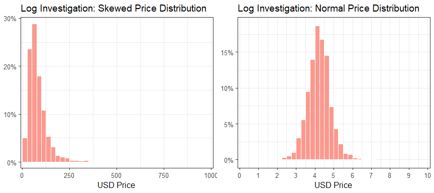

|  | Median | Min | Max | P25 | P75 | P95 | N |
| --- | --- | --- | --- | --- | --- | --- | --- |
| usd_daily_price | 67.98 | 1.13 | 1118.27 | 45.32 | 99.70 | 179.01 | 9014 |

|  |  | N | % |
| --- | --- | --- | --- |
| f_room_type | Entire home/apt | 7250 | 80.4 |
|  | Hotel room | 0 | 0.0 |
|  | Private room | 1764 | 19.6 |
| f_room_type2 | Entire/Apt | 7250 | 80.4 |
|  | Private | 1764 | 19.6 |
| f_neighbourhood_cleansed | Alsergrund | 591 | 6.6 |
|  | Brigittenau | 332 | 3.7 |
|  | Dbling | 179 | 2.0 |
|  | Donaustadt | 240 | 2.7 |
|  | Favoriten | 528 | 5.9 |
|  | Floridsdorf | 80 | 0.9 |
|  | Hernals | 238 | 2.6 |
|  | Hietzing | 105 | 1.2 |
|  | Innere Stadt | 498 | 5.5 |
|  | Josefstadt | 347 | 3.8 |
|  | Landstra§e | 811 | 9.0 |
|  | Leopoldstadt | 989 | 11.0 |
|  | Liesing | 37 | 0.4 |
|  | Margareten | 502 | 5.6 |
|  | Mariahilf | 438 | 4.9 |
|  | Meidling | 388 | 4.3 |
|  | Neubau | 552 | 6.1 |
|  | Ottakring | 463 | 5.1 |
|  | Penzing | 221 | 2.5 |
|  | Rudolfsheim-Fnfhaus | 708 | 7.9 |
|  | Simmering | 103 | 1.1 |
|  | Whring | 265 | 2.9 |
|  | Wieden | 399 | 4.4 |
| d_iron | 0 | 2665 | 29.6 |
|  | 1 | 6349 | 70.4 |
| d_dedicated_workspace | 0 | 2393 | 26.5 |
|  | 1 | 6621 | 73.5 |
| d_crib | 0 | 7828 | 86.8 |
|  | 1 | 1186 | 13.2 |
| d_heating | 0 | 938 | 10.4 |
|  | 1 | 8076 | 89.6 |
| d_long_term_stays | 0 | 1104 | 12.2 |
|  | 1 | 7910 | 87.8 |
| d_free_street_parking | 0 | 8397 | 93.2 |
|  | 1 | 617 | 6.8 |
| d_patio_balcony | 0 | 8069 | 89.5 |
|  | 1 | 945 | 10.5 |
| d_elevator | 0 | 4670 | 51.8 |
|  | 1 | 4344 | 48.2 |
| d_dishwasher | 0 | 5510 | 61.1 |
|  | 1 | 3504 | 38.9 |
| d_washer | 0 | 2210 | 24.5 |
|  | 1 | 6804 | 75.5 |
| neighbourhood_cleansed | Alsergrund | 591 | 6.6 |
|  | Brigittenau | 332 | 3.7 |
|  | Dbling | 179 | 2.0 |
|  | Donaustadt | 240 | 2.7 |
|  | Favoriten | 528 | 5.9 |
|  | Floridsdorf | 80 | 0.9 |
|  | Hernals | 238 | 2.6 |
|  | Hietzing | 105 | 1.2 |
|  | Innere Stadt | 498 | 5.5 |
|  | Josefstadt | 347 | 3.8 |
|  | Landstra§e | 811 | 9.0 |
|  | Leopoldstadt | 989 | 11.0 |
|  | Liesing | 37 | 0.4 |
|  | Margareten | 502 | 5.6 |
|  | Mariahilf | 438 | 4.9 |
|  | Meidling | 388 | 4.3 |
|  | Neubau | 552 | 6.1 |
|  | Ottakring | 463 | 5.1 |
|  | Penzing | 221 | 2.5 |
|  | Rudolfsheim-Fnfhaus | 708 | 7.9 |
|  | Simmering | 103 | 1.1 |
|  | Whring | 265 | 2.9 |
|  | Wieden | 399 | 4.4 |
| room_type | Entire home/apt | 7250 | 80.4 |
|  | Private room | 1764 | 19.6 |
| property_type | Entire loft | 156 | 1.7 |
|  | Entire rental unit | 6771 | 75.1 |
|  | Entire serviced apartment | 323 | 3.6 |
|  | Private room in rental unit | 1764 | 19.6 |

Furthermore, we will check interaction terms for the conditional distributions of price in USD daily. It can be observed that there are different patterns for price with different categories based on each of these variables.

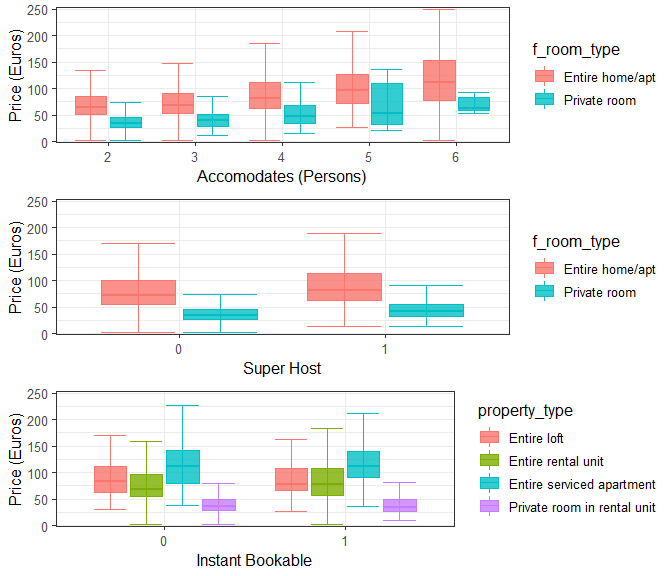

### Predictive Models with Random Forest

After immense data cleaning and filtering we will divide our data into test and train sets. The training set includes 70% of the observations and the test set will include the remaining 30% of the observations. We will run our model on the training set using usd_daily_price as the dependent variable. The train was 6312 observations in total while the test set included 2702 observations. In this study we will create basic variables, reviews, and dummy variables followed by 1 set of interaction terms for LASSO, and 1 set of polynomial expressions. The table below enlists all the variables used in the study.

```r
##Defining models: Simpler and extended
#Basic Variables (including neighborhood)
basic_vars <- c(
  "n_accommodates", "n_beds", "n_days_since_first_review",
  "n_days_since_last_review", "property_type","f_room_type", "n_bathroom_number",
  "neighbourhood_cleansed")

#Reviews
reviews <- c("n_number_of_reviews", "flag_n_number_of_reviews" ,
             "n_review_scores_rating", "flag_review_scores_accuracy",
             "flag_review_scores_cleanliness", "flag_review_scores_checkin",
             "flag_review_scores_communication", "flag_review_scores_location",
             "flag_review_scores_value", "flag_reviews_per_month")

#Dummy variables from amenities and others
amenities <-  c("d_iron", "d_dedicated_workspace", "d_crib", "d_heating",
                "d_long_term_stays", "d_free_street_parking", "d_patio_balcony",
                "d_elevator", "d_dishwasher", "d_washer", "d_host_is_superhost",
                "d_instant_bookable")

#Poly and log variables
poly_log_vars <- c("n_accommodates2", "ln_beds",
                   "ln_number_of_reviews", "ln_days_since_first_review2",
                   "ln_days_since_first_review3", "ln_days_since_last_review2",
                   "ln_days_since_last_review3", "n_days_since_first_review2",
                   "n_days_since_first_review3", "n_days_since_last_review2",
                   "n_days_since_last_review3", "ln_review_scores_rating",
                   "n_reviews_per_month2", "n_reviews_per_month3")

#Interaction terms for LASSO
X1  <- c("n_accommodates*property_type",  "f_room_type*property_type",
         "f_room_type*d_crib", "d_long_term_stays*property_type",
         "d_patio_balcony*property_type", "d_elevator*property_type")
X2  <- c("property_type*f_neighbourhood_cleansed",
         "f_room_type*f_neighbourhood_cleansed",
         "n_accommodates*f_neighbourhood_cleansed" )

predictors_1 <- c(basic_vars)
predictors_2 <- c(basic_vars, reviews, amenities)
predictors_3 <- c(basic_vars, reviews, amenities, X1, X2)
predictors_4 <- c(basic_vars, reviews, amenities, X1, X2, poly_log_vars)
```

In this study, we wil create 3 models using random forest. The first **model 1** will be a simple model with basic variables only. **Model 2** will be more complex containing basic variables, reviews and dummy variables. Lastly, **Model 3** is the auto-tuned model consisting of all 3 sets of variables.